# Exercise 2

### 問題

講座内容に関するアンケート直近５０名分dataを基に  
**評価が変化したか** を検定する  
↓  
平均値とかこの平均値を比べる  
↓  
それぞれの数値に **有意差** があるかを **検定** で確かめる

1. data を読み込む
   - **csv 自体でも内容を確認**
2. histograme で確認
   - **色々階級を変えて確認**
3. 平均と標準偏差を求め検定に必要な統計量を算出
   - **それぞれの統計量が棄却域に入るかを確認**
4. R の関数 t.test を使って確認

### 1. csv file 読み込み

- working dirctory 確認

```r
getwd()
```

```
[1] "/home/rstudio/r_rstudio/statistics/02_inferential"
```

```r
data <- read.csv("data02_mac.csv")
data
```

| 参加者 | 年齢 | 性別 | 設問1 | 設問2 | 設問3 | 設問4 | 設問5 |
| --- | --- | --- | --- | --- | --- | --- | --- |
| 1 | 22 | 男性 | 5 | 2 | 4 | 1 | 5 |
| 2 | 40 | 女性 | 4 | 2 | 4 | 1 | 4 |
| 3 | 28 | 男性 | 4 | 2 | 4 | 4 | 3 |
| 4 | 34 | 女性 | 3 | 1 | 4 | 4 | 4 |
| 5 | 33 | 女性 | 4 | 2 | 5 | 3 | 4 |
| 6 | 38 | 男性 | 4 | 1 | 4 | 5 | 5 |
| 7 | 38 | 男性 | 5 | 3 | 4 | 3 | 4 |
| 8 | 42 | 男性 | 5 | 2 | 5 | 2 | 3 |
| 9 | 50 | 女性 | 5 | 3 | 4 | 4 | 4 |
| 10 | 20 | 女性 | 4 | 3 | 5 | 3 | 5 |

[output cut: 40 more lines]

### 2. histograme で確認

- まずは histograme で確認
- **年齢**

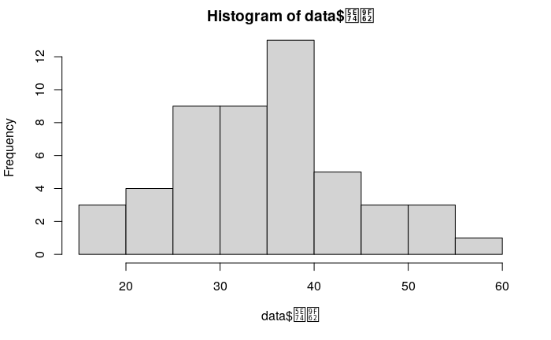

```r
hist(data$年齢)
```

- **設問１**
  - 3, 4, 5 の高評価が多い

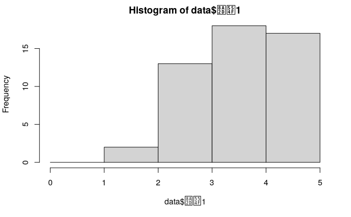

```r
hist(data$設問1, breaks = seq(0, 5, 1))
```

- **設問2**
  - 1, 2, 3 の低評価が多い

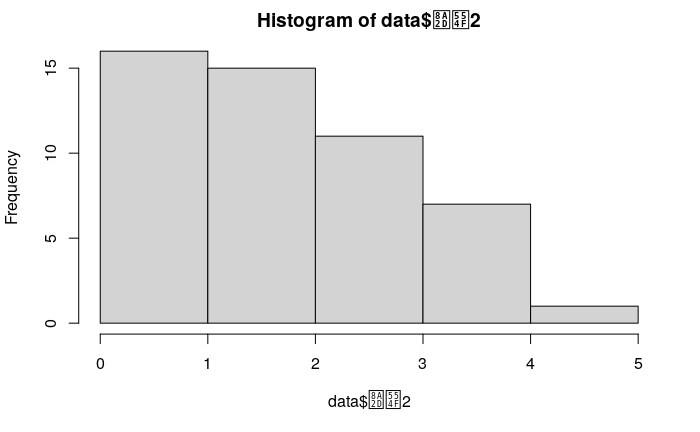

```r
hist(data$設問2, breaks = seq(0, 5, 1))
```

- **設問3**
  - 4, 5 のしかない

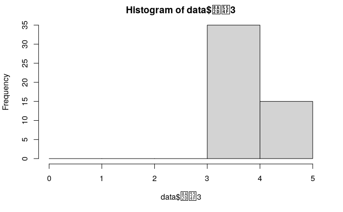

```r
hist(data$設問3, breaks = seq(0, 5, 1))
```

- **設問4**
  - 満遍なく広がっている

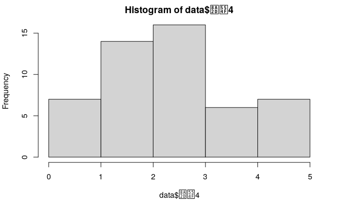

```r
hist(data$設問4, breaks = seq(0, 5, 1))
```

- **設問5**
  - 3, 4, 5 が多い傾向がある

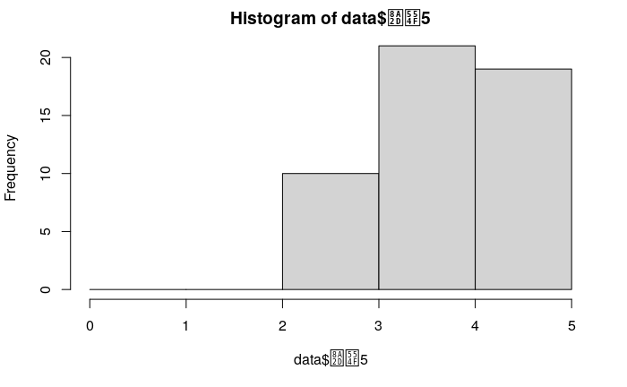

```r
hist(data$設問5, breaks = seq(0, 5, 1))
```

### 3. 平均と標準偏差を求め検定に必要な統計量を算出

- **それぞれの統計量が棄却域に入るかを確認**

| 設問 | これまでの平均 |
| --- | --- |
| 1 | 3.5 |
| 2 | 2.5 |
| 3 | 4.2 |
| 4 | 3.2 |
| 5 | 3.7 |

#### 検定

| 設問１ | 値 |
| --- | --- |
| **現在の平均値** | 4 |
| **標準偏差** | 0.8806306 |
| **これまでの平均値** | 3.5 |
| **標本数** | 50 |
| **統計量** | 4.0147753 |

```r
xm <- mean(data$設問1)
xm
```

```
[1] 4
```

```r
s1 <- sd(data$設問1)
m1 <- 3.5
n1 <- nrow(data)
```

$$標準化　=　\frac{\overline{X} - \mu}{\frac{\sigma}{\sqrt{n}}}$$

```r
z1 <- (xm - m1)/(s1 / sqrt(n1))
```

#### 統計量の結果から

- **統計量** : 4.0147753
  - 95%で検定をした場合, **珍しいことが起きている区間にあたる** ので…
    - 平均値が 3.5 -> 4 に上がっていたということは, **有意差** があり意味がある数である

### 上記を for文で回す

- for 文で 設問 1 ~ 5までの統計量を求める

```r
mm = c(3.5, 2.5, 4.2, 3.2, 3.7)
mm
```

```
[1] 3.5 2.5 4.2 3.2 3.7
```

```r
xx = rep(0, 5)
xx
```

```
[1] 0 0 0 0 0
```

```r
zz = rep(0, 5)
zz
```

```
[1] 0 0 0 0 0
```

- **mm** : 3.5, 2.5, 4.2, 3.2, 3.7
  - 基の平均値を配列に入れる
- **xx**
  - 0の配列を作成 & 平均を入れる入れ物を作成
- **zz**
  - 0の配列を作成 & 統計量を入れる入れ物を作成

```r
for (i in 1:5) {
  xx[i] = mean(data[,3+i])
  zz[i] = (mean(data[,3+i]) - mm[i]) / (sd(data[,3+i]) / sqrt(n1))
}
xx
```

```
[1] 4.00 2.24 4.30 2.84 4.18
```

```r
zz
```

```
[1]  4.014775 -1.646132  1.527525 -2.061423  4.540541
```

#### for文後の検定結果

| 統計量 | 数値 | 基の$\mu$ | 現在$\mu$ | 有意差 |
| --- | --- | --- | --- | --- |
| **設問1 統計量** | 4.0147753 | 3.5 | 4 | 有(+なので良い) |
| **設問2 統計量** | -1.6461322 | 2.5 | 2.24 | 無し(よくある事) |
| **設問3 統計量** | 1.5275252 | 4.2 | 4.3 | 無し(よくある事) |
| **設問4 統計量** | -2.061423 | 3.2 | 2.84 | 有（-なので注意） |
| **設問5 統計量** | 4.5405405 | 3.7 | 4.18 | 有(+なので良い) |